# Prédiction de l’émission de CO2 d’une voiture en fonction de ses caractéristiques

JEAN-BAPTiSTE Knight Peterson & MULOT Brice

2025-03-31

## **1- INTRODUCTION**

### **1.1- Présentation**

### **1.1.1-Problématique**

Dans le cadre de l’analyse des données sur les émissions de CO2 des voitures, nous cherchons à :

### **1.1.2-Tableau : Liste des objectifs**

[output not shown]

### **1.1.3-Tableau : Plan de la présentation**

| **Étape** | **Contenu** |
| --- | --- |
| **Exploration des données** | - Présentation des variables |
|  | - Première visualisation des variables |
| **Pré-traitement des données** | - Nettoyage des données |
|  | - Imputation des valeurs manquantes |
|  | - Encodage des variables catégorielles |
| **Visualisation des données** | - Visualisation des relations entre les variables et les émissions de CO2 |
| **Analyse factorielle** | - ACP (Analyse en Composantes Principales) |
| **Modélisation des émissions de CO2** | - Régression linéaire |
|  | - Régression Ridge et Lasso |
|  | - Vérification des hypothèses et validation des modèles |
| **Évaluation des modèles** | - Comparaison des performances des modèles |
|  | - Analyse des résidus et tests statistiques |
| **Conclusion** | - Résumé des résultats |
|  | - Recommandations basées sur les modèles |

### **1.2-Jeu de données**

Ce jeu de données prise via l’API du gouvernement liée au site : https://carlabelling.ademe.fr/ contient des informations détaillées sur les caractéristiques techniques et les émissions de CO2 de divers véhicules en France. Les données couvrent une période allant de 2001 à 2015, offrant une vue d’ensemble des tendances en matière d’émissions de CO2 dans l’industrie automobile.

## **2**- **Exploration et Prétraitement des données**

### **2.1-Import des outils**

```python
import pandas as pd
import numpy as np
import matplotlib.pyplot as plt
import seaborn as sns
from sklearn.impute import SimpleImputer
from sklearn.preprocessing import MinMaxScaler
import statsmodels.api as sm
from statsmodels.stats.stattools import durbin_watson
from sklearn.compose import ColumnTransformer
from sklearn.decomposition import PCA
from sklearn.preprocessing import StandardScaler
from scipy.stats import kstest, boxcox, jarque_bera, probplot
import statsmodels.formula.api as smf
from statsmodels.stats.outliers_influence import variance_inflation_factor
from statsmodels.stats.diagnostic import het_breuschpagan, linear_rainbow
from scipy import stats
from statsmodels.stats.diagnostic import lilliefors, linear_rainbow
from statsmodels.stats.stattools import durbin_watson
from statsmodels.stats.diagnostic import acorr_ljungbox
from statsmodels.stats.diagnostic import acorr_breusch_godfrey
from statsmodels.stats.diagnostic import het_breuschpagan
```

### **2.2-Compréhension de la Structure**

```python
from google.colab import files
uploaded = files.upload()
```

### **2.3-Lecture des données**

```python
df = pd.read_csv('vehicules-commercialises.csv', sep=';')
```

### **2.4-Présentation des variables**

```python
df.head()
```

|  | Marque | Modèle dossier | Modèle commercial | Désignation commerciale | CNIT | Type Variante Version (TVV) | Carburant | Hybride | Puissance administrative | Puissance maximale | … | HC | NOx | HC+NOx | Particules | Masse vide euro min | Masse vide euro max | Champ v9 | Année | Carrosserie | Gamme |
| --- | --- | --- | --- | --- | --- | --- | --- | --- | --- | --- | --- | --- | --- | --- | --- | --- | --- | --- | --- | --- | --- |
| 0 | CITROEN | C1 5P 1.0i | C1 5P 1.0i | C1 5P 1.0i | MCT1012TR301 | MCT1012TR301 | Essence | NaN | 4.0 | 50.0 | … | NaN | NaN | NaN | NaN | NaN | NaN | NaN | 2008 | NaN | NaN |
| 1 | TOYOTA | AYGO 3P 1.0 VVT-i | AYGO 3P 1.0 VVT-i | AYGO 3P 1.0 VVT-i | MJT1071V7879 | MJT1071V7879 | Essence | NaN | 4.0 | 50.0 | … | NaN | NaN | NaN | NaN | NaN | NaN | NaN | 2008 | NaN | NaN |
| 2 | TOYOTA | AYGO 3P 1.0 VVT-i MultiMode | AYGO 3P 1.0 VVT-i MultiMode | AYGO 3P 1.0 VVT-i MultiMode | MJT3071VP115 | MJT3071VP115 | Essence | NaN | 4.0 | 50.0 | … | NaN | NaN | NaN | NaN | NaN | NaN | NaN | 2008 | NaN | NaN |
| 3 | SMART | SMART FORTWO 1.0L BVM5 | SMART FORTWO 1.0L BVM5 | SMART FORTWO 1.0L BVM5 | MST1001DY331 | MST1001DY331 | Essence | NaN | 4.0 | 45.0 | … | NaN | NaN | NaN | NaN | NaN | NaN | NaN | 2008 | NaN | NaN |
| 4 | SMART | SMART FORFOUR 1.3L BVA6 | SMART FORFOUR 1.3L BVA6 | SMART FORFOUR 1.3L BVA6 | MST3204C1278 | MST3204C1278 | Essence | NaN | 5.0 | 70.0 | … | NaN | NaN | NaN | NaN | NaN | NaN | NaN | 2008 | NaN | NaN |

5 rows × 26 columns

### **2.4.1-Variables**

1. **Marque** : La marque du véhicule.
2. **Modèle dossier** : Le modèle du véhicule tel qu’il est référencé dans les dossiers administratifs.
3. **Modèle commercial** : Le nom commercial du modèle du véhicule.
4. **Désignation commerciale** : La désignation commerciale complète du véhicule, souvent utilisée pour le marketing.
5. **CNIT** : Code National d’Identification du Type de véhicule.
6. **Type Variante Version (TVV)** : Identifie la variante spécifique du modèle de véhicule.
7. **Carburant** : Le type de carburant utilisé par le véhicule (ex. essence, diesel).
8. **Hybride** : Indique si le véhicule est hybride ou non.
9. **Puissance administrative** : La puissance fiscale du véhicule, utilisée pour le calcul des taxes.
10. **Puissance maximale** : La puissance maximale du moteur en chevaux (ch).
11. **Boîte de vitesse** : Le type de boîte de vitesse (manuelle, automatique, etc.).
12. **Consommation urbaine** : La consommation de carburant en cycle urbain (litres/100 km).
13. **Consommation extra-urbaine** : La consommation de carburant en cycle extra-urbain (litres/100 km).
14. **Consommation mixte** : La consommation moyenne de carburant en cycle mixte (litres/100 km).
15. **CO2** : Les émissions de dioxyde de carbone en grammes par kilomètre (g/km).
16. **CO type I** : Les émissions de monoxyde de carbone (CO) en conditions de type I.
17. **HC** : Les émissions d’hydrocarbures imbrûlés (HC).
18. **NOx** : Les émissions d’oxydes d’azote (NOx).
19. **HC+NOx** : Les émissions combinées d’hydrocarbures et d’oxydes d’azote.
20. **Particules** : Les émissions de particules fines.
21. **Masse vide euro min** : La masse minimale à vide du véhicule en kilogrammes.
22. **Masse vide euro max** : La masse maximale à vide du véhicule en kilogrammes.
23. **Champ v9** : Une colonne supplémentaire, potentiellement utilisée pour des informations spécifiques ou des annotations.
24. **Année** : L’année de fabrication du véhicule.
25. **Carrosserie** : Le type de carrosserie du véhicule (ex. berline, SUV).
26. **Gamme** : La gamme ou la catégorie du véhicule dans la ligne de produits du constructeur.

```python
print('Dimension de la dataframe :', df.shape, '\n')
df.info()
```

```
Dimension de la dataframe : (305701, 26)

<class 'pandas.core.frame.DataFrame'>
RangeIndex: 305701 entries, 0 to 305700
Data columns (total 26 columns):
 #   Column                       Non-Null Count   Dtype
---  ------                       --------------   -----
 0   Marque                       305701 non-null  object
 1   Modèle dossier               305701 non-null  object
 2   Modèle commercial            305701 non-null  object
 3   Désignation commerciale      305701 non-null  object
 4   CNIT                         305689 non-null  object
 5   Type Variante Version (TVV)  260893 non-null  object
 6   Carburant                    305701 non-null  object
 7   Hybride                      159780 non-null  object
```

[output cut: 20 more lines]

### **2.5-Nettoyage des données**

```python
df.isnull().sum()
```

|  | 0 |
| --- | --- |
| Marque | 0 |
| Modèle dossier | 0 |
| Modèle commercial | 0 |
| Désignation commerciale | 0 |
| CNIT | 12 |
| Type Variante Version (TVV) | 44808 |
| Carburant | 0 |
| Hybride | 145921 |
| Puissance administrative | 4204 |
| Puissance maximale | 4273 |
| Boîte de vitesse | 4163 |
| Consommation urbaine | 4478 |
| Consommation extra-urbaine | 4478 |
| Consommation mixte | 4398 |
| CO2 | 4398 |
| CO type I | 146611 |
| HC | 268888 |
| NOx | 146611 |
| HC+NOx | 183249 |
| Particules | 155458 |
| Masse vide euro min | 145831 |
| Masse vide euro max | 145831 |
| Champ v9 | 108278 |
| Année | 0 |
| Carrosserie | 166801 |
| Gamme | 166801 |

**dtype:** int64

On va ici commencer par supprimer les colonnes CO type I / HC / NOx / HC+NOx / Particules car ce sont des émissions liées mais différentes du CO₂, puis les colonnes CNIT / TVV / Désignation commerciale / Marque / Modèle car ce sont des identifiants ou catégories trop spécifiques.

```python
drops = ('CO type I', 'HC', 'NOx', 'HC+NOx', 'Champ v9', 'Particules', 'CNIT', 'Type Variante Version (TVV)', 'Désignation commerciale', 'Marque', 'Modèle dossier', 'Modèle commercial', 'Gamme', 'Carrosserie')
for drop in drops:
    df = df.drop(drop, axis = 1)

df.isnull().sum()
```

|  | 0 |
| --- | --- |
| Carburant | 0 |
| Hybride | 145921 |
| Puissance administrative | 4204 |
| Puissance maximale | 4273 |
| Boîte de vitesse | 4163 |
| Consommation urbaine | 4478 |
| Consommation extra-urbaine | 4478 |
| Consommation mixte | 4398 |
| CO2 | 4398 |
| Masse vide euro min | 145831 |
| Masse vide euro max | 145831 |
| Année | 0 |

**dtype:** int64

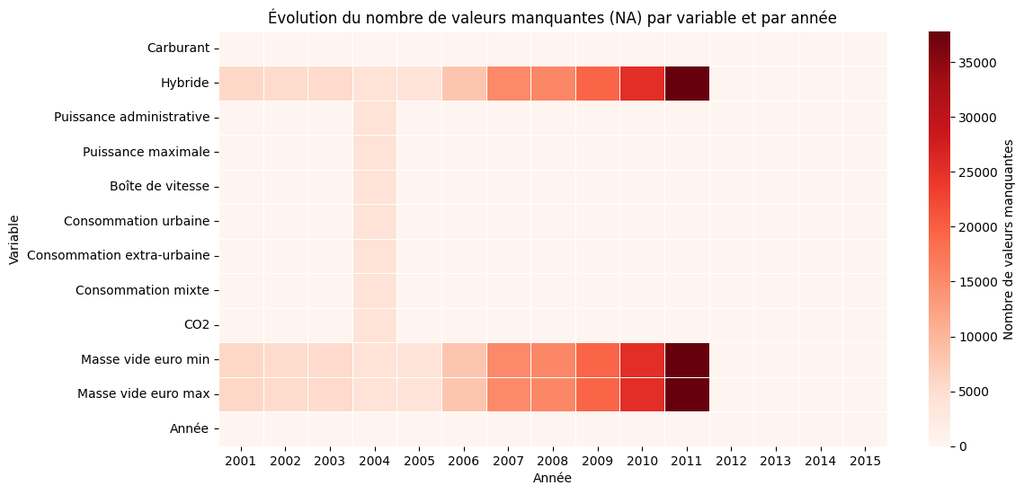

png

```python
# Vérifier que 'Année' est bien une colonne numérique
df['Année'] = pd.to_numeric(df['Année'], errors='coerce')

# Calculer le nombre de valeurs manquantes par année et par variable
na_counts = df.groupby("Année").apply(lambda x: x.isna().sum())

# Création du graphique
plt.figure(figsize=(12, 6))
sns.heatmap(na_counts.T, cmap="Reds", linewidths=0.5, cbar_kws={'label': 'Nombre de valeurs manquantes'})

plt.xlabel("Année")
plt.ylabel("Variable")
plt.title("Évolution du nombre de valeurs manquantes (NA) par variable et par année")
plt.show()
```

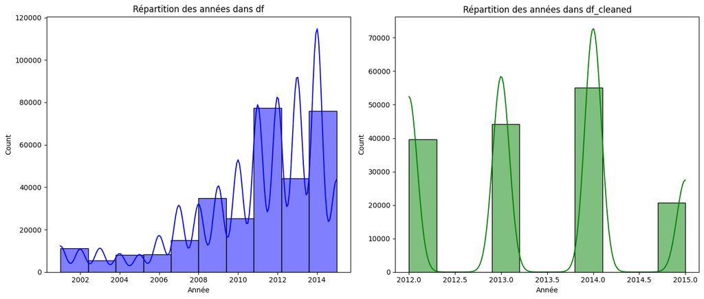

png

```python
df_cleaned = df.dropna()
# Création des graphiques
plt.figure(figsize=(14, 6))

# Premier graphique pour df
plt.subplot(1, 2, 1)
sns.histplot(df['Année'], kde=True, color='blue', bins=10)
plt.title('Répartition des années dans df')

# Deuxième graphique pour df_cleaned
plt.subplot(1, 2, 2)
sns.histplot(df_cleaned['Année'], kde=True, color='green', bins=10)
plt.title('Répartition des années dans df_cleaned')

# Afficher les graphiques
plt.tight_layout()
plt.show()
```

Ici on peut voir qu’après nettoyage, les données sont principalement concentrées sur les années 2012, 2013, et 2014.Il y a une perte significative d’informations sur les autres années, ce qui signifie que les données nettoyées ne représentent plus toute la période initiale.

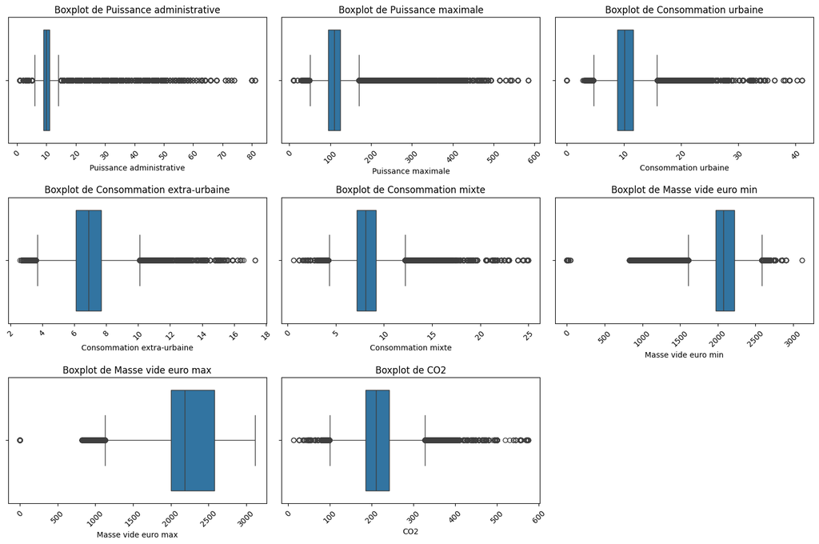

png

```python
# Sélectionner les variables numériques pour les boxplots
numerical_cols = [
    "Puissance administrative", "Puissance maximale", "Consommation urbaine",
    "Consommation extra-urbaine", "Consommation mixte", "Masse vide euro min",
    "Masse vide euro max", "CO2"
]

# Initialiser la figure pour les boxplots
plt.figure(figsize=(15, 10))

# Créer un boxplot pour chaque variable numérique
for i, col in enumerate(numerical_cols):
    plt.subplot(3, 3, i + 1)  # Disposition en 3x3
    sns.boxplot(data=df, x=col)
    plt.title(f"Boxplot de {col}")
    plt.xticks(rotation=45)

# Afficher les boxplots
plt.tight_layout()
plt.show()
```

On peut voir beaucoup de valeurs extrêmes pour chacune des variables on va donc préféré utiliser la médiane pour les valeurs manquantes

```python
# Créer un imputer pour remplir les valeurs manquantes avec la médiane
imputer_num = SimpleImputer(strategy='median')  # Remplir avec la médiane

# Appliquer l'imputation aux colonnes numériques
df[numerical_cols] = imputer_num.fit_transform(df[numerical_cols])

# Vérifier les valeurs manquantes après imputation
print(df.isnull().sum())  # Devrait montrer 0 pour toutes les colonnes numériques
```

```
Carburant                          0
Hybride                       145921
Puissance administrative           0
Puissance maximale                 0
Boîte de vitesse                4163
Consommation urbaine               0
Consommation extra-urbaine         0
Consommation mixte                 0
CO2                                0
Masse vide euro min                0
Masse vide euro max                0
Année                              0
dtype: int64
```

```python
df.Hybride.value_counts()
```

| Hybride | count |
| --- | --- |
| Non hybride | 157977 |
| Hybride | 1803 |

**dtype:** int64

```python
categorical_cols = ["Boîte de vitesse", "Hybride"]
df[categorical_cols] = df[categorical_cols].fillna("Autre")
print(df.isnull().sum())
```

```
Carburant                     0
Hybride                       0
Puissance administrative      0
Puissance maximale            0
Boîte de vitesse              0
Consommation urbaine          0
Consommation extra-urbaine    0
Consommation mixte            0
CO2                           0
Masse vide euro min           0
Masse vide euro max           0
Année                         0
dtype: int64
```

### **3 - Analyse exploratoire des données**

### **3.1-Statistiques Descriptives**

```python
# Statistiques descriptives
print("Statistiques descriptives :")
print(df.describe())
```

```
Statistiques descriptives :
       Puissance administrative  Puissance maximale  Consommation urbaine  \
count             305701.000000       305701.000000         305701.000000
mean                  11.192433          122.163669             10.521886
std                    6.507268           56.323398              3.235754
min                    1.000000           10.000000              0.000000
25%                    9.000000           95.000000              8.800000
50%                   10.000000          110.000000             10.100000
75%                   11.000000          125.000000             11.600000
max                   81.000000          585.000000             41.100000

       Consommation extra-urbaine  Consommation mixte            CO2  \
count               305701.000000       305701.000000  305701.000000
mean                     6.884793            8.213086     210.561071
std                      1.573978            2.137985      51.157349
min                      2.600000            0.600000      13.000000
25%                      6.200000            7.200000     186.000000
50%                      6.900000            8.100000     211.000000
75%                      7.700000            9.200000     241.000000
max                     17.300000           25.000000     575.000000

       Masse vide euro min  Masse vide euro max          Année
count        305701.000000        305701.000000  305701.000000
mean           2066.634002          2192.258108    2010.879366
std             246.686956           318.250728       3.350196
min               0.000000             0.000000    2001.000000
25%            2076.000000          2185.000000    2009.000000
50%            2076.000000          2185.000000    2012.000000
75%            2076.000000          2185.000000    2013.000000
max            3115.000000          3115.000000    2015.000000
```

### **3.2- Visualisations**

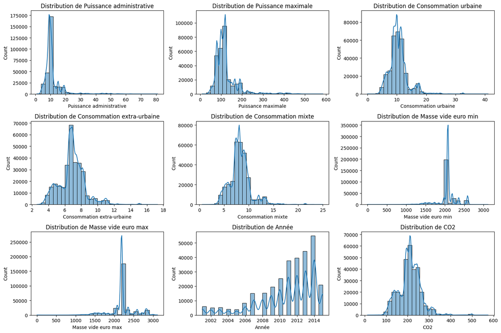

png

```python
# Histogrammes des variables numériques

numerical_cols = [
    "Puissance administrative", "Puissance maximale", "Consommation urbaine",
    "Consommation extra-urbaine", "Consommation mixte", "Masse vide euro min",
    "Masse vide euro max", "Année", "CO2"
]

plt.figure(figsize=(15, 10))
for i, col in enumerate(numerical_cols):
    plt.subplot(3, 3, i + 1)
    sns.histplot(df[col], kde=True, bins=30)
    plt.title(f"Distribution de {col}")
plt.tight_layout()
plt.show()
```

Ces histogrammes montrent que la plupart des véhicules ont des caractéristiques modérées en termes de puissance, consommation, masse et émissions de CO2. Cependant, il existe des variations notables, avec certains véhicules ayant des valeurs extrêmes. Ces informations sont essentielles pour comprendre la distribution des caractéristiques des véhicules et pour identifier les tendances et les anomalies dans les données.

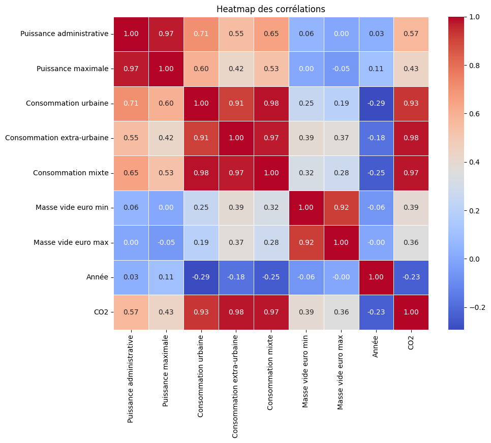

png

```python
# Matrice de corrélation (heatmap)
plt.figure(figsize=(10, 8))
sns.heatmap(df[numerical_cols].corr(), annot=True, cmap="coolwarm", fmt=".2f", linewidths=0.5)
plt.title("Heatmap des corrélations")
plt.show()
```

Cette heatmap montre que les variables liées à la puissance, la consommation de carburant, la masse, et les émissions de CO2 sont fortement interconnectées. Les véhicules plus puissants et plus lourds tendent à consommer plus de carburant et à émettre plus de CO2. Les années des véhicules ont une influence modérée sur la consommation, suggérant des améliorations possibles dans l’efficacité énergétique des véhicules plus récents.

On peut supprimer la consommation urbaine / consommation extra-urbaine car fortement corréler avec consommation mixte de même pourMasse video euro min et max et puissance maximale et puissance administrative

```python
drops = ('Consommation urbaine', 'Consommation extra-urbaine', 'Puissance maximale', 'Masse vide euro max')
for drop in drops:
    df = df.drop(drop, axis = 1)
```

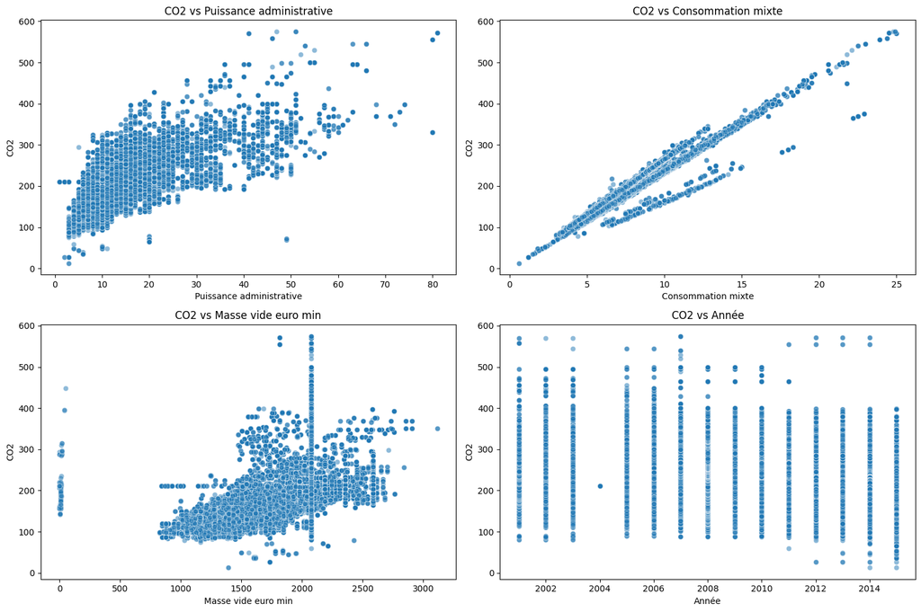

png

```python
# Scatterplots pour voir la relation entre CO₂ et d'autres variables
variables_explicatives = ["Puissance administrative", "Consommation mixte", "Masse vide euro min", "Année"]

plt.figure(figsize=(15, 10))
for i, col in enumerate(variables_explicatives):
    plt.subplot(2, 2, i + 1)
    sns.scatterplot(data=df, x=col, y="CO2", alpha=0.5)
    plt.title(f"CO2 vs {col}")
plt.tight_layout()
plt.show()
```

La variable qui semble avoir la relation la plus forte et la plus claire avec les émissions de CO2 est la consommation mixte, avec une corrélation positive évidente.

La puissance administrative et la masse vide montrent des tendances à la hausse des émissions de CO2, mais avec beaucoup de variabilité, ce qui suggère que ces facteurs ne sont pas les seuls à influencer les émissions.

L’année montre une tendance encourageante à la baisse des émissions de CO2, probablement due à des avancées technologiques et à des réglementations plus strictes.

## **4- Préparation des données**

### **4.1 - Encodage des variables catégorielles**

L’objectif de cette variable est de convertir nos variables catégorielles en variables numériques afin de pouvoir les utiliser conjointement dans nos analyses. Pour cela, nous appliquons la fonction *get_dummies* aux colonnes *Carburant* et *Boîte de Vitesse*. Cette transformation permet de créer une colonne distincte pour chaque catégorie de ces variables, facilitant ainsi leur exploitation dans nos modèles.

```python
import pandas as pd

# One-Hot Encoding pour "Carburant" et "Boîte de vitesse"
df = pd.get_dummies(df, columns=["Carburant", "Boîte de vitesse"], drop_first=True)

# Label Encoding pour "Hybride"
df["Hybride"] = df["Hybride"].map({"Hybride": 1, "Non hybride": 0, "Autre": 0})  # On met "Autre" à 0 par défaut

# Convertir les colonnes booléennes en numériques
for col in df.select_dtypes(include=['bool']).columns:
    df[col] = df[col].astype(int)

# Vérification du dataframe après encodage
df.head()
```

|  | Hybride | Puissance administrative | Consommation mixte | CO2 | Masse vide euro min | Année | Carburant_EE | Carburant_EH | Carburant_EL | Carburant_EN | … | Boîte de vitesse_M 7 | Boîte de vitesse_M5 | Boîte de vitesse_M6 | Boîte de vitesse_N | Boîte de vitesse_N 0 | Boîte de vitesse_N 1 | Boîte de vitesse_S 6 | Boîte de vitesse_V . | Boîte de vitesse_V 0 | Boîte de vitesse_V 1 |
| --- | --- | --- | --- | --- | --- | --- | --- | --- | --- | --- | --- | --- | --- | --- | --- | --- | --- | --- | --- | --- | --- |
| 0 | 0 | 4.0 | 4.6 | 108.0 | 2076.0 | 2008 | 0 | 0 | 0 | 0 | … | 0 | 0 | 0 | 0 | 0 | 0 | 0 | 0 | 0 | 0 |
| 1 | 0 | 4.0 | 4.6 | 108.0 | 2076.0 | 2008 | 0 | 0 | 0 | 0 | … | 0 | 0 | 0 | 0 | 0 | 0 | 0 | 0 | 0 | 0 |
| 2 | 0 | 4.0 | 4.6 | 109.0 | 2076.0 | 2008 | 0 | 0 | 0 | 0 | … | 0 | 0 | 0 | 0 | 0 | 0 | 0 | 0 | 0 | 0 |
| 3 | 0 | 4.0 | 4.7 | 112.0 | 2076.0 | 2008 | 0 | 0 | 0 | 0 | … | 0 | 0 | 0 | 0 | 0 | 0 | 0 | 0 | 0 | 0 |
| 4 | 0 | 5.0 | 5.6 | 133.0 | 2076.0 | 2008 | 0 | 0 | 0 | 0 | … | 0 | 0 | 0 | 0 | 0 | 0 | 0 | 0 | 0 | 0 |

5 rows × 52 columns

### **4.2 - Encodages des données**

Deux options courantes :

1. Standardisation : Centrer les données (moyenne = 0, écart-type = 1) → Utile si les données suivent une distribution normale.
2. Min-Max Scaling : Mettre les valeurs entre 0 et 1 → Utile si les données ont des échelles différentes et doivent être comparées.

```python
# Sélection des colonnes numériques à normaliser
numerical_cols = [
    "Puissance administrative", "Consommation mixte", "Masse vide euro min", "Année", "CO2"
]

# Appliquer la normalisation Min-Max Scaling
scaler = MinMaxScaler()
df[numerical_cols] = scaler.fit_transform(df[numerical_cols])

# Vérification du résultat
df.head()
```

|  | Hybride | Puissance administrative | Consommation mixte | CO2 | Masse vide euro min | Année | Carburant_EE | Carburant_EH | Carburant_EL | Carburant_EN | … | Boîte de vitesse_M 7 | Boîte de vitesse_M5 | Boîte de vitesse_M6 | Boîte de vitesse_N | Boîte de vitesse_N 0 | Boîte de vitesse_N 1 | Boîte de vitesse_S 6 | Boîte de vitesse_V . | Boîte de vitesse_V 0 | Boîte de vitesse_V 1 |
| --- | --- | --- | --- | --- | --- | --- | --- | --- | --- | --- | --- | --- | --- | --- | --- | --- | --- | --- | --- | --- | --- |
| 0 | 0 | 0.0375 | 0.163934 | 0.169039 | 0.666453 | 0.5 | 0 | 0 | 0 | 0 | … | 0 | 0 | 0 | 0 | 0 | 0 | 0 | 0 | 0 | 0 |
| 1 | 0 | 0.0375 | 0.163934 | 0.169039 | 0.666453 | 0.5 | 0 | 0 | 0 | 0 | … | 0 | 0 | 0 | 0 | 0 | 0 | 0 | 0 | 0 | 0 |
| 2 | 0 | 0.0375 | 0.163934 | 0.170819 | 0.666453 | 0.5 | 0 | 0 | 0 | 0 | … | 0 | 0 | 0 | 0 | 0 | 0 | 0 | 0 | 0 | 0 |
| 3 | 0 | 0.0375 | 0.168033 | 0.176157 | 0.666453 | 0.5 | 0 | 0 | 0 | 0 | … | 0 | 0 | 0 | 0 | 0 | 0 | 0 | 0 | 0 | 0 |
| 4 | 0 | 0.0500 | 0.204918 | 0.213523 | 0.666453 | 0.5 | 0 | 0 | 0 | 0 | … | 0 | 0 | 0 | 0 | 0 | 0 | 0 | 0 | 0 | 0 |

5 rows × 52 columns

## **5 - Vérification avant la regression**

### **5.1 - Le Modèle**

On a le modèle suivant :

$$Y_{i} = \sum_{j = 0}^{p} a_{j}X_{i,j} +
\epsilon_{i}$$
pour $i = 1, ..., n$

où $X_{0,j} = 1$

La variable Y est la variable à expliquer et les variables $X_{i}$ sont les variables explicatives.  
Les variables $a_{j}$, (où $j = 0, ..., p$) sont les paramètres à estimer de notre modèle.  
Les $\epsilon_{i}$ sont les erreurs.

On peut aussi écrire ce modèle sous la forme matricielle suivante : $Y = XA + \epsilon$

### **5.2 - Les hypothèses**

Nous devrons vérifier les hypothèses suivantes :

*Hypothèses à priori :*

1. $r(X_{i},Y) != 0$ (toutes les corrélations ne doivent pas être nulles)
2. La matrice X est de plein rang : les $X_{i}$ ne sont pas colinéaires (ils sont linéairement indépendants) : cela assure que $X^{T}X$ est inversible.
3. n ? p + 1 il faut savoir ce qu’on a à la place de ? (<, >, =) ce qui revient à résoudre le modèle de régression linéaire c’est-à-dire une équation à n équations et p inconnues
- si n = p + 1, la “droite de régression” est celle qui passe par tous les points
- si n > p + 1, une unique solution
- si n < p + 1, une infinité de solution

*Hypothèses a posteriori :*

4. $\mathbb{E}(\epsilon_{i})=0$, $Var(\epsilon_{i})=\sigma²)$ et les $\epsilon_{i}$ sont non corrélés. De plus, on doit avoir $cov(X_{i}, \epsilon_{i}) = 0$
5. Les $\epsilon_{i}$ sont normales.

### **5.3 - Estimation des moindres carrés ordinaire (MCO)**

Un **estimateur Â** du vecteur A peut être trouvé par **la méthode d’estimation des moindres carrés ordinaire** (possible grâce à l’hypothèse numéro 2).  
L’objectif est de trouver le paramètre A qui minimise la somme des carrés des erreurs entre les valeurs prévues et observées.

Voici son expression $Â = (X^{T}X)^{-1}X^{T}Y$

**Cet estimateur a les propriétés suivantes :** 1. Il est sans biais : $\mathbb{E}(Â) = A$

2. C’est le le meilleur estimateur sans biais linéaire (il est de variance minimum) : il est appelé *BLUE* (Best Linear Unbiased Estimator).
3. Sous l’hypothèse de normalité des $\epsilon_{i}$, Â est l’estimateur du maximum de vraisemblance. Il est donc efficace. De plus, Â ~ $\mathcal{N}(A, \sigma²(X^{T}X)^{-1})$
4. Â $\to^{\mathcal{L}} \mathcal{N}(A, \dfrac{\sigma²Q^{-1}}{n})$. Si l’hypothèse de normalité n’est pas vérifiée mais que l’hypothèse $\dfrac{X^{T}X}{n} \to Q$ (inversible) est vérifiée, le résultat est valide.
5. Â est convergent en probabilité.

**Loi des paramètres :** - $Var(Â) = \sigma²(X^{T}X)^{-1}$ - La variance des $a_{j}$ est $\sigma²_{a_{j}} = [\sigma²(X^{T}X)^{-1}]_{j,j}$ On peut remplacer $\sigma²$ par son estimateur sans biais $s²$.

### **5.4 - Vérifications des hypothèses à priori**

### Il existe des corrélation non nulles

```
Corrélations entre chaque Xi et Y :
Toutes les corrélations sont non nulles : True
Matrice de corrélation :



Passing `palette` without assigning `hue` is deprecated and will be removed in v0.14.0. Assign the `y` variable to `hue` and set `legend=False` for the same effect.

  sns.barplot(
```

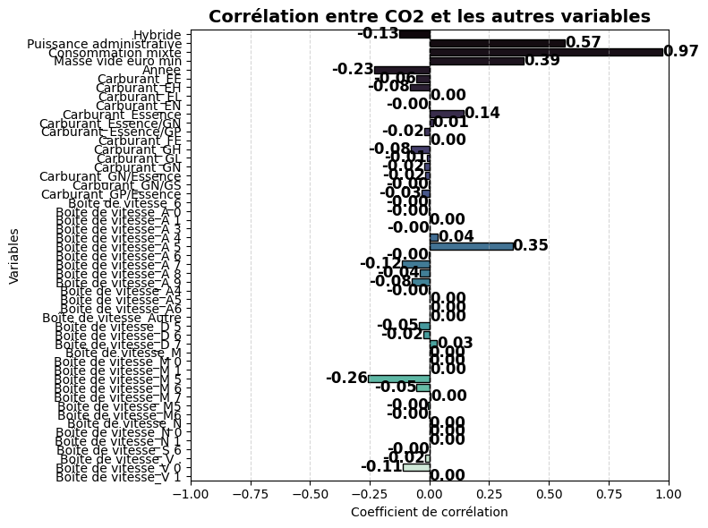

png

```python
# Calcul des corrélations entre chaque Xi et Y
correlations = df.corr().loc['CO2', df.columns != 'CO2']

# Vérifier que toutes les corrélations sont non nulles
correlations_non_nulles = (correlations != 0).all()

print("Corrélations entre chaque Xi et Y :")
print(f"Toutes les corrélations sont non nulles : {correlations_non_nulles}")

correlation_matrix = df.corr()

print("Matrice de corrélation :")

plt.figure(figsize=(8, 6))
sns.barplot(
    x=correlations.values,
    y=correlations.index,
    palette="mako",  # Choix d'une belle palette de couleurs
    edgecolor="black"
)

for i, value in enumerate(correlations.values):
    plt.text(value, i, f"{value:.2f}", va="center", ha="right" if value < 0 else "left", fontsize=12, fontweight="bold")

plt.title("Corrélation entre CO2 et les autres variables", fontsize=14, fontweight="bold")
plt.xlabel("Coefficient de corrélation")
plt.ylabel("Variables")
plt.axvline(x=0, color="black", linestyle="--", linewidth=1)
plt.xlim(-1, 1)
plt.grid(axis="x", linestyle="--", alpha=0.5)
plt.tight_layout()

plt.show()
```

### Matrice X de plein rang

```python
# Conversion en matrice numpy
X = df.to_numpy()

# Vérifier si X est de plein rang
rang_X = np.linalg.matrix_rank(X)
plein_rang = rang_X == min(X.shape)

# Vérifier si X^T X est inversible
XtX = X.T @ X
inversible = np.linalg.det(XtX) != 0

print(f"Rang de X : {rang_X}")
print(f"X est de plein rang : {plein_rang}")
print(f"X^T X est inversible : {inversible}")
```

```
Rang de X : 52
X est de plein rang : True
X^T X est inversible : True
```

### Comparaison entre n et p + 1

```python
# Déterminer n (nombre d'observations) et p (nombre de prédicteurs)
n = df.shape[0]  # Nombre d'observations
p = df.shape[1] - 1  # Nombre de variables explicatives (sans CO2)
p1 = p + 1  # p + 1

# Comparaison entre n et p + 1
if n == p1:
    situation = "n = p + 1 : la droite de régression passe par tous les points."
elif n > p1:
    situation = "n > p + 1 : il existe une unique solution."
else:
    situation = "n < p + 1 : il y a une infinité de solutions."

print(f"n = {n}, p + 1 = {p1}")
print(situation)
```

```
n = 305701, p + 1 = 52
n > p + 1 : il existe une unique solution.
```

## **6 - Régression Linéaire**

## **6.1 - MCO**

```python
import pandas as pd
import statsmodels.api as sm
from sklearn.model_selection import train_test_split

X = df.drop('CO2', axis=1)
y = df['CO2']

# Division en jeu d'entraînement et de test
X_train, X_test, y_train, y_test = train_test_split(X, y, test_size=0.2, random_state=42)

# Ajout d'une constante pour le modèle OLS
X_train_const = sm.add_constant(X_train)
X_test_const = sm.add_constant(X_test)  # Ajout de la constante aux données de test

# Entraînement du modèle sur les données d'entraînement
model = sm.OLS(y_train, X_train_const)
results = model.fit()

# Prédictions sur X_test
y_pred = results.predict(X_test_const)

# Affichage des premières prédictions
print(results.summary())
```

```
                            OLS Regression Results
==============================================================================
Dep. Variable:                    CO2   R-squared:                       0.994
Model:                            OLS   Adj. R-squared:                  0.994
Method:                 Least Squares   F-statistic:                 7.887e+05
Date:                Fri, 21 Mar 2025   Prob (F-statistic):               0.00
Time:                        12:50:46   Log-Likelihood:             8.6378e+05
No. Observations:              244560   AIC:                        -1.727e+06
Df Residuals:                  244508   BIC:                        -1.727e+06
Df Model:                          51
Covariance Type:            nonrobust
============================================================================================
                               coef    std err          t      P>|t|      [0.025      0.975]
--------------------------------------------------------------------------------------------
const                        0.0141      0.004      3.459      0.001       0.006       0.022
Hybride                      0.0027      0.001      3.972      0.000       0.001       0.004
Puissance administrative    -0.0534      0.000   -184.601      0.000      -0.054      -0.053
Consommation mixte           1.0980      0.000   3749.038      0.000       1.097       1.099
Masse vide euro min          0.0086      0.000     40.426      0.000       0.008       0.009
Année                       -0.0080   7.87e-05   -101.774      0.000      -0.008      -0.008
Carburant_EE                -0.0214      0.001    -21.095      0.000      -0.023      -0.019
Carburant_EH                -0.0328      0.001    -45.677      0.000      -0.034      -0.031
Carburant_EL                -0.0033      0.001     -4.081      0.000      -0.005      -0.002
Carburant_EN                -0.1478      0.005    -29.537      0.000      -0.158      -0.138
Carburant_Essence           -0.0384   4.54e-05   -846.787      0.000      -0.039      -0.038
Carburant_Essence/GN        -0.0432      0.000   -103.569      0.000      -0.044      -0.042
Carburant_Essence/GP        -0.0411      0.001    -82.133      0.000      -0.042      -0.040
Carburant_FE                -0.1317      0.000   -306.888      0.000      -0.133      -0.131
Carburant_GH                -0.0093      0.001    -12.307      0.000      -0.011      -0.008
Carburant_GL                -0.0096      0.004     -2.320      0.020      -0.018      -0.001
Carburant_GN                -0.1404      0.001   -216.840      0.000      -0.142      -0.139
Carburant_GN/Essence        -0.1527      0.000   -365.620      0.000      -0.153      -0.152
Carburant_GN/GS             -0.1195      0.007    -16.877      0.000      -0.133      -0.106
Carburant_GP/Essence        -0.1755      0.000   -363.430      0.000      -0.176      -0.175
Boîte de vitesse_6           0.0052      0.006      0.808      0.419      -0.007       0.018
Boîte de vitesse_A 0         0.0099      0.004      2.335      0.020       0.002       0.018
Boîte de vitesse_A 1         0.0082      0.005      1.567      0.117      -0.002       0.018
Boîte de vitesse_A 3         0.0018      0.005      0.395      0.693      -0.007       0.011
Boîte de vitesse_A 4         0.0071      0.004      1.747      0.081      -0.001       0.015
Boîte de vitesse_A 5         0.0118      0.004      2.898      0.004       0.004       0.020
```

[output cut: 22 more lines]

```
Boîte de vitesse_S 6         0.0099      0.005      1.976      0.048    7.99e-05       0.020
Boîte de vitesse_V .         0.0122      0.004      2.775      0.006       0.004       0.021
Boîte de vitesse_V 0         0.0079      0.004      1.941      0.052   -7.56e-05       0.016
Boîte de vitesse_V 1         0.0077      0.008      0.933      0.351      -0.008       0.024
==============================================================================
Omnibus:                   249753.473   Durbin-Watson:                   1.997
Prob(Omnibus):                  0.000   Jarque-Bera (JB):        303111244.624
Skew:                          -4.061   Prob(JB):                         0.00
Kurtosis:                     175.279   Cond. No.                     2.58e+03
==============================================================================

Notes:
[1] Standard Errors assume that the covariance matrix of the errors is correctly specified.
[2] The condition number is large, 2.58e+03. This might indicate that there are
strong multicollinearity or other numerical problems.
```

On en refait en supprimant toute les variables ayant une p.value > 0.05

```python
# Filtrer les variables ayant p-value > 0.05

significant_vars = results.pvalues[results.pvalues >= 0.05].index
X_filtered = X.drop(significant_vars, axis=1)  # Garder seulement les variables significatives

# Division en jeu d'entraînement et de test
X_train, X_test, y_train, y_test = train_test_split(X_filtered, y, test_size=0.2, random_state=42)

# Ajout d'une constante pour le modèle OLS
X_train_const = sm.add_constant(X_train)
X_test_const = sm.add_constant(X_test)  # Ajout de la constante aux données de test

# Entraînement du modèle sur les données d'entraînement
model = sm.OLS(y_train, X_train_const)
results = model.fit()

# Prédictions sur X_test
y_pred = results.predict(X_test_const)

# Affichage des premières prédictions
print(results.summary())
```

```
                            OLS Regression Results
==============================================================================
Dep. Variable:                    CO2   R-squared:                       0.994
Model:                            OLS   Adj. R-squared:                  0.994
Method:                 Least Squares   F-statistic:                 1.087e+06
Date:                Fri, 21 Mar 2025   Prob (F-statistic):               0.00
Time:                        12:50:48   Log-Likelihood:             8.6376e+05
No. Observations:              244560   AIC:                        -1.727e+06
Df Residuals:                  244522   BIC:                        -1.727e+06
Df Model:                          37
Covariance Type:            nonrobust
============================================================================================
                               coef    std err          t      P>|t|      [0.025      0.975]
--------------------------------------------------------------------------------------------
const                        0.0216      0.000    124.330      0.000       0.021       0.022
Hybride                      0.0029      0.001      4.277      0.000       0.002       0.004
Puissance administrative    -0.0534      0.000   -185.631      0.000      -0.054      -0.053
Consommation mixte           1.0979      0.000   3765.960      0.000       1.097       1.099
Masse vide euro min          0.0086      0.000     40.540      0.000       0.008       0.009
Année                       -0.0080   7.82e-05   -102.310      0.000      -0.008      -0.008
Carburant_EE                -0.0215      0.001    -21.248      0.000      -0.024      -0.020
Carburant_EH                -0.0327      0.001    -45.521      0.000      -0.034      -0.031
Carburant_EL                -0.0032      0.001     -4.892      0.000      -0.004      -0.002
Carburant_EN                -0.1478      0.005    -29.535      0.000      -0.158      -0.138
Carburant_Essence           -0.0384   4.52e-05   -849.982      0.000      -0.039      -0.038
Carburant_Essence/GN        -0.0432      0.000   -103.539      0.000      -0.044      -0.042
Carburant_Essence/GP        -0.0411      0.000    -82.506      0.000      -0.042      -0.040
Carburant_FE                -0.1317      0.000   -306.872      0.000      -0.132      -0.131
Carburant_GH                -0.0095      0.001    -12.603      0.000      -0.011      -0.008
Carburant_GL                -0.0098      0.004     -2.373      0.018      -0.018      -0.002
Carburant_GN                -0.1404      0.001   -216.830      0.000      -0.142      -0.139
Carburant_GN/Essence        -0.1527      0.000   -365.590      0.000      -0.153      -0.152
Carburant_GN/GS             -0.1195      0.007    -16.876      0.000      -0.133      -0.106
Carburant_GP/Essence        -0.1755      0.000   -364.031      0.000      -0.176      -0.175
Boîte de vitesse_A 0         0.0024      0.001      2.230      0.026       0.000       0.004
Boîte de vitesse_A 5         0.0044      0.000     42.953      0.000       0.004       0.005
Boîte de vitesse_A 6         0.0017      0.000     13.472      0.000       0.001       0.002
Boîte de vitesse_A 7         0.0046      0.000     43.526      0.000       0.004       0.005
Boîte de vitesse_A 8         0.0050      0.000     27.143      0.000       0.005       0.005
Boîte de vitesse_A5          0.0075      0.004      1.826      0.068      -0.001       0.015
Boîte de vitesse_A6          0.0057      0.002      2.404      0.016       0.001       0.010
Boîte de vitesse_Autre       0.0176      0.000    113.825      0.000       0.017       0.018
Boîte de vitesse_D 5         0.0063      0.001     11.861      0.000       0.005       0.007
Boîte de vitesse_D 6         0.0068      0.001      7.566      0.000       0.005       0.009
Boîte de vitesse_D 7         0.0096      0.001     11.728      0.000       0.008       0.011
Boîte de vitesse_M 5         0.0011      0.000     10.153      0.000       0.001       0.001
Boîte de vitesse_M 6         0.0036      0.000     35.831      0.000       0.003       0.004
Boîte de vitesse_M 7         0.0128      0.001     17.545      0.000       0.011       0.014
Boîte de vitesse_M5          0.0026      0.002      1.446      0.148      -0.001       0.006
Boîte de vitesse_M6          0.0016      0.002      0.801      0.423      -0.002       0.005
Boîte de vitesse_S 6         0.0025      0.003      0.848      0.397      -0.003       0.008
Boîte de vitesse_V .         0.0044      0.002      2.765      0.006       0.001       0.008
==============================================================================
Omnibus:                   249691.361   Durbin-Watson:                   1.997
Prob(Omnibus):                  0.000   Jarque-Bera (JB):        302769233.081
Skew:                          -4.059   Prob(JB):                         0.00
Kurtosis:                     175.182   Cond. No.                         769.
==============================================================================

Notes:
[1] Standard Errors assume that the covariance matrix of the errors is correctly specified.
```

### **6.2 - VIF**

Le **VIF (Variance Inflation Factor)** est une mesure utilisée pour détecter la **multicolinéarité** dans un modèle de régression. Il quantifie l’augmentation de la variance d’un coefficient estimé due à la corrélation avec les autres variables explicatives.

Mathématiquement, le **VIF** pour la variable $X_j$ est défini comme suit :

$VIF(Xj)=\dfrac1{1-R_j^{2}}$

où $R_j^{2}$ est le coefficient de détermination obtenu en régressant la variable $Xj$ sur toutes les autres variables explicatives du modèle.

**Interprétation** : Un VIF élevé (généralement supérieur à 10) indique une forte colinéarité entre $X_j$ et les autres variables, ce qui peut rendre l’estimation des coefficients instable. Un VIF proche de 1 signifie qu’il n’y a pas de colinéarité entre $X_j$ et les autres variables explicatives.

```python
from statsmodels.stats.outliers_influence import variance_inflation_factor

# Calcul du VIF pour chaque variable
vif_data = pd.DataFrame()
vif_data["Variable"] = X_filtered.columns
vif_data["VIF"] = [variance_inflation_factor(X_filtered.values, i) for i in range(X_filtered.shape[1])]

# Filtrer les VIF > 10 et trier par ordre décroissant
vif_data_filtered = vif_data[vif_data["VIF"] > 10].sort_values("VIF", ascending=False)

# Affichage des résultats filtrés
print(vif_data_filtered)
```

```
                Variable        VIF
3    Masse vide euro min  51.379338
2     Consommation mixte  42.477783
31  Boîte de vitesse_M 6  17.067522
4                  Année  14.235123
0                Hybride  13.617606
20  Boîte de vitesse_A 5  11.624617
```

```python
test = X_filtered.drop(['Boîte de vitesse_M 6', 'Boîte de vitesse_A 7', 'Boîte de vitesse_A 5', 'Masse vide euro min'], axis=1)
# Calcul du VIF pour chaque variable
vif_data = pd.DataFrame()
vif_data["Variable"] = test.columns
vif_data["VIF"] = [variance_inflation_factor(test.values, i) for i in range(test.shape[1])]

# Filtrer les VIF > 10 et trier par ordre décroissant
vif_data_filtered = vif_data[vif_data["VIF"] > 10].sort_values("VIF", ascending=False)

# Affichage des résultats filtrés
print(vif_data_filtered)

# Division en jeu d'entraînement et de test
X_train, X_test, y_train, y_test = train_test_split(test, y, test_size=0.2, random_state=42)

# Ajout d'une constante pour le modèle OLS
X_train_const = sm.add_constant(X_train)
X_test_const = sm.add_constant(X_test)  # Ajout de la constante aux données de test

# Entraînement du modèle sur les données d'entraînement
model = sm.OLS(y_train, X_train_const)
results = model.fit()

# Prédictions sur X_test
y_pred = results.predict(X_test_const)

# Affichage des premières prédictions
print(results.summary())
```

```
             Variable        VIF
0             Hybride  13.590185
2  Consommation mixte  11.089830
                            OLS Regression Results
==============================================================================
Dep. Variable:                    CO2   R-squared:                       0.994
Model:                            OLS   Adj. R-squared:                  0.994
Method:                 Least Squares   F-statistic:                 1.199e+06
Date:                Fri, 21 Mar 2025   Prob (F-statistic):               0.00
Time:                        12:54:29   Log-Likelihood:             8.6173e+05
No. Observations:              244560   AIC:                        -1.723e+06
Df Residuals:                  244526   BIC:                        -1.723e+06
Df Model:                          33
Covariance Type:            nonrobust
============================================================================================
                               coef    std err          t      P>|t|      [0.025      0.975]
--------------------------------------------------------------------------------------------
const                        0.0290      0.000    287.767      0.000       0.029       0.029
Hybride                      0.0020      0.001      2.919      0.004       0.001       0.003
Puissance administrative    -0.0530      0.000   -195.088      0.000      -0.054      -0.052
Consommation mixte           1.1034      0.000   4399.893      0.000       1.103       1.104
Année                       -0.0072   7.66e-05    -94.042      0.000      -0.007      -0.007
Carburant_EE                -0.0199      0.001    -19.529      0.000      -0.022      -0.018
Carburant_EH                -0.0347      0.001    -48.048      0.000      -0.036      -0.033
Carburant_EL                -0.0089      0.001    -13.855      0.000      -0.010      -0.008
Carburant_EN                -0.1481      0.005    -29.351      0.000      -0.158      -0.138
Carburant_Essence           -0.0393   4.17e-05   -942.043      0.000      -0.039      -0.039
Carburant_Essence/GN        -0.0438      0.000   -104.372      0.000      -0.045      -0.043
Carburant_Essence/GP        -0.0423      0.001    -84.204      0.000      -0.043      -0.041
Carburant_FE                -0.1327      0.000   -307.044      0.000      -0.134      -0.132
Carburant_GH                -0.0080      0.001    -10.460      0.000      -0.009      -0.006
Carburant_GL                -0.0079      0.004     -1.893      0.058      -0.016       0.000
Carburant_GN                -0.1412      0.001   -216.380      0.000      -0.143      -0.140
Carburant_GN/Essence        -0.1534      0.000   -364.839      0.000      -0.154      -0.153
Carburant_GN/GS             -0.1198      0.007    -16.780      0.000      -0.134      -0.106
Carburant_GP/Essence        -0.1771      0.000   -365.293      0.000      -0.178      -0.176
Boîte de vitesse_A 0        -0.0003      0.001     -0.241      0.809      -0.002       0.002
Boîte de vitesse_A 6        -0.0024   8.34e-05    -29.304      0.000      -0.003      -0.002
Boîte de vitesse_A 8         0.0010      0.000      6.278      0.000       0.001       0.001
Boîte de vitesse_A5          0.0036      0.004      0.884      0.377      -0.004       0.012
Boîte de vitesse_A6          0.0019      0.002      0.803      0.422      -0.003       0.007
Boîte de vitesse_Autre       0.0145      0.000    110.120      0.000       0.014       0.015
Boîte de vitesse_D 5         0.0013      0.001      2.379      0.017       0.000       0.002
Boîte de vitesse_D 6         0.0020      0.001      2.221      0.026       0.000       0.004
Boîte de vitesse_D 7         0.0040      0.001      4.927      0.000       0.002       0.006
Boîte de vitesse_M 5        -0.0022   6.52e-05    -34.385      0.000      -0.002      -0.002
Boîte de vitesse_M 7         0.0076      0.001     10.455      0.000       0.006       0.009
Boîte de vitesse_M5         -0.0004      0.002     -0.198      0.843      -0.004       0.003
Boîte de vitesse_M6         -0.0018      0.002     -0.895      0.371      -0.006       0.002
Boîte de vitesse_S 6        -0.0016      0.003     -0.560      0.575      -0.007       0.004
Boîte de vitesse_V .         0.0026      0.002      1.617      0.106      -0.001       0.006
==============================================================================
Omnibus:                   251647.334   Durbin-Watson:                   1.998
Prob(Omnibus):                  0.000   Jarque-Bera (JB):        300465249.915
Skew:                          -4.126   Prob(JB):                         0.00
Kurtosis:                     174.517   Cond. No.                         643.
==============================================================================

Notes:
[1] Standard Errors assume that the covariance matrix of the errors is correctly specified.
```

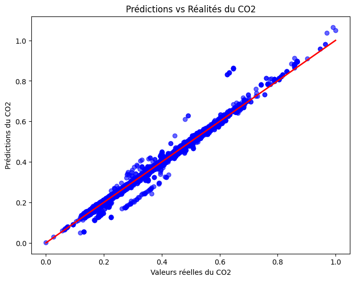

png

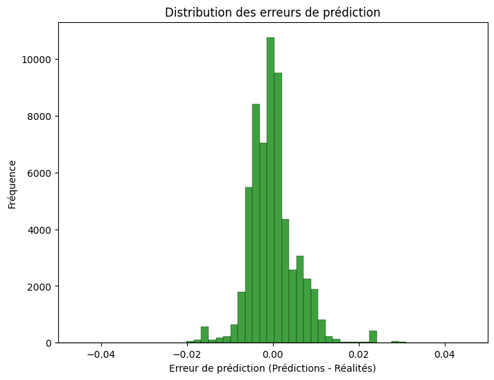

png

```python
import matplotlib.pyplot as plt
import seaborn as sns
import numpy as np

# Visualisation des prédictions vs valeurs réelles
plt.figure(figsize=(8, 6))
plt.scatter(y_test, y_pred, color='blue', alpha=0.6)
plt.plot([min(y_test), max(y_test)], [min(y_test), max(y_test)], color='red', linewidth=2)
plt.title('Prédictions vs Réalités du CO2')
plt.xlabel('Valeurs réelles du CO2')
plt.ylabel('Prédictions du CO2')
plt.show()

# Visualisation de l'erreur de prédiction
plt.figure(figsize=(8, 6))
errors = y_pred - y_test
sns.histplot(errors, color='green', bins=200)
plt.title('Distribution des erreurs de prédiction')
plt.xlabel('Erreur de prédiction (Prédictions - Réalités)')
plt.ylabel('Fréquence')
plt.xlim(-0.05, 0.05)
plt.show()
```

```python
# Calcul des résidus
residuals = results.resid

# Test de Shapiro-Wilk (Normalité)
shapiro_stat, shapiro_p_value = stats.shapiro(residuals)

# Test de Lilliefors (Normalité)
lilliefors_stat, lilliefors_p_value = lilliefors(residuals)

# Test de Ljung-Box (Autocorrélation des résidus)
ljungbox_stat, ljungbox_p_value = acorr_ljungbox(residuals, lags=10)  # Par défaut, 10 lags

# Test de Box-Pierce (Autocorrélation des résidus)
boxpierce = sm.stats.acorr_ljungbox(residuals, boxpierce=True, lags=[10], return_df=True)

# Test de Breusch-Godfrey (Autocorrélation)
breuschgodfrey = acorr_breusch_godfrey(results, nlags=10)

# Test de Durbin-Watson (Autocorrélation des résidus)
dw_stat = durbin_watson(residuals)

# Test de Linear Rainbow (Linéarité)
rainbow_stat, rainbow_p_value = linear_rainbow(results)

# Test de Student (Hypothèse de significativité des coefficients)
student_stat, student_p_value = stats.ttest_1samp(residuals, 0)  # Test de Student sur les résidus

# Affichage des résultats
print(f"Shapiro-Wilk Test: Stat = {shapiro_stat}, p-value = {shapiro_p_value}")
print(f"Lilliefors Test: Stat = {lilliefors_stat}, p-value = {lilliefors_p_value}")
print(f"Ljung-Box Test: Stat = {ljungbox_stat}, p-value = {ljungbox_p_value}")
print(f"Ljung-Box Test: Stat = {boxpierce['lb_stat'].values[0]}, p-value = {boxpierce['lb_pvalue'].values[0]}")
print(f"Box-Pierce Test: Stat = {boxpierce['bp_stat'].values[0]}, p-value = {boxpierce['bp_pvalue'].values[0]}")
print(f"Breusch-Godfrey Test: Stat = {breuschgodfrey[0]}, p-value = {breuschgodfrey[1]}")
print(f"Durbin-Watson Test: Stat = {dw_stat}")
print(f"Linear Rainbow Test: Stat = {rainbow_stat}, p-value = {rainbow_p_value}")
print(f"Student's t-test: Stat = {student_stat}, p-value = {student_p_value}")
```

[output not shown]

### **6.3- ACP**

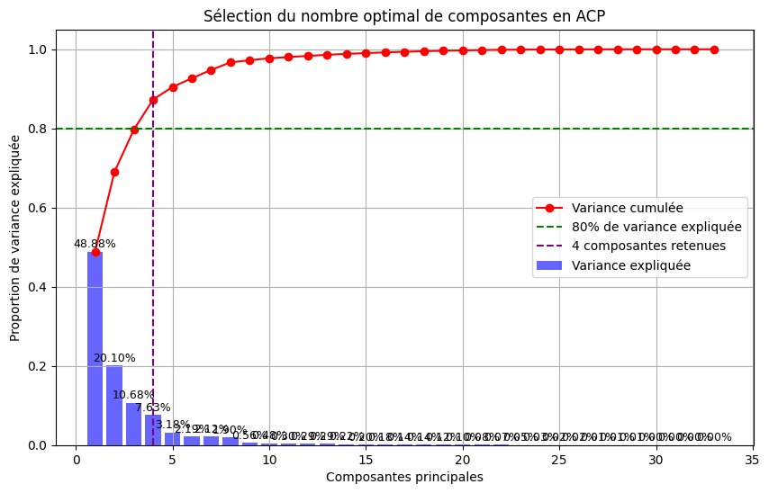

png

```python
import numpy as np
import matplotlib.pyplot as plt
from sklearn.decomposition import PCA

# Appliquer l'ACP sur tes données scale (df déjà centré-réduit)
pca = PCA()
pca.fit(test)

# Variance expliquée par chaque composante
variance_expliquee = pca.explained_variance_ratio_
variance_cumulee = np.cumsum(variance_expliquee)

# Nombre optimal de composantes pour atteindre 80% de variance expliquée
nb_composantes = np.argmax(variance_cumulee >= 0.80) + 1

# Tracé du graphe
fig, ax = plt.subplots(figsize=(10, 6))

# Histogramme (variance expliquée)
ax.bar(range(1, len(variance_expliquee) + 1), variance_expliquee, alpha=0.6, color='b', label="Variance expliquée")

# Courbe de la variance cumulée
ax.plot(range(1, len(variance_cumulee) + 1), variance_cumulee, marker='o', color='r', label="Variance cumulée")

# Ajout des valeurs en pourcentage sur les barres
for i, v in enumerate(variance_expliquee):
    ax.text(i + 1, v + 0.01, f"{v*100:.2f}%", ha='center', fontsize=9)

# Ligne horizontale pour le seuil de 80%
ax.axhline(y=0.80, color='g', linestyle='--', label="80% de variance expliquée")

# Ligne verticale pour le nombre optimal de composantes
ax.axvline(x=nb_composantes, color='purple', linestyle='--', label=f"{nb_composantes} composantes retenues")

# Légendes et titres
ax.set_xlabel("Composantes principales")
ax.set_ylabel("Proportion de variance expliquée")
ax.set_title("Sélection du nombre optimal de composantes en ACP")
ax.legend()
ax.grid(True)

# Afficher le graphe
plt.show()
```

```python
# Appliquer l'ACP avec 4 composantes
pca = PCA(n_components=8)
X_pca = pca.fit_transform(test)

# Séparer les données en train et test
X_train, X_test, y_train, y_test = train_test_split(X_pca, y, test_size=0.2, random_state=42)

# Ajout d'une constante pour le modèle OLS
X_train_const = sm.add_constant(X_train)
X_test_const = sm.add_constant(X_test)  # Ajout de la constante aux données de test

# Entraînement du modèle sur les données d'entraînement
model = sm.OLS(y_train, X_train_const)
results = model.fit()

# Prédictions sur X_test
y_pred = results.predict(X_test_const)

# Affichage des premières prédictions
print(results.summary())
```

```
                            OLS Regression Results
==============================================================================
Dep. Variable:                    CO2   R-squared:                       0.860
Model:                            OLS   Adj. R-squared:                  0.860
Method:                 Least Squares   F-statistic:                 1.881e+05
Date:                Fri, 21 Mar 2025   Prob (F-statistic):               0.00
Time:                        12:55:33   Log-Likelihood:             4.7961e+05
No. Observations:              244560   AIC:                        -9.592e+05
Df Residuals:                  244551   BIC:                        -9.591e+05
Df Model:                           8
Covariance Type:            nonrobust
==============================================================================
                 coef    std err          t      P>|t|      [0.025      0.975]
------------------------------------------------------------------------------
const          0.3516   6.88e-05   5106.465      0.000       0.351       0.352
x1             0.0292      0.000    186.297      0.000       0.029       0.029
x2            -0.0699      0.000   -286.434      0.000      -0.070      -0.069
x3            -0.1906      0.000   -567.907      0.000      -0.191      -0.190
x4            -0.0628      0.000   -158.885      0.000      -0.064      -0.062
x5            -0.2997      0.001   -487.254      0.000      -0.301      -0.298
x6            -0.0248      0.001    -33.610      0.000      -0.026      -0.023
x7             0.2446      0.001    324.957      0.000       0.243       0.246
x8             0.6602      0.001    830.970      0.000       0.659       0.662
==============================================================================
Omnibus:                    76075.220   Durbin-Watson:                   2.005
Prob(Omnibus):                  0.000   Jarque-Bera (JB):           359549.318
Skew:                          -1.446   Prob(JB):                         0.00
Kurtosis:                       8.188   Cond. No.                         11.5
==============================================================================

Notes:
[1] Standard Errors assume that the covariance matrix of the errors is correctly specified.
```

Nous remarquons que le modèle explique 86 % de la variabilité des données (R² = 0.860), ce qui est très satisfaisant. Tous les coefficients sont statistiquement significatifs (p-value < 0.05). Les variables x1, x7 et x8 ont un impact positif sur les émissions de CO2 (coefficients positifs), avec x8 ayant l’effet le plus fort (0.6602). En revanche, x2, x3, x4, x5 et x6 réduisent les émissions (coefficients négatifs), x5 ayant l’effet négatif le plus marqué (-0.2997). Le test de Durbin-Watson (2.005) indique une absence d’autocorrélation des résidus, mais les tests d’Omnibus et Jarque-Bera suggèrent une non-normalité des résidus, ce qui pourrait nécessiter une transformation des données.”

```python
# Calcul des résidus
residuals = results.resid

# Test de Shapiro-Wilk (Normalité)
shapiro_stat, shapiro_p_value = stats.shapiro(residuals)

# Test de Lilliefors (Normalité)
lilliefors_stat, lilliefors_p_value = lilliefors(residuals)

# Test de Ljung-Box (Autocorrélation des résidus)
ljungbox_stat, ljungbox_p_value = acorr_ljungbox(residuals, lags=10)  # Par défaut, 10 lags

# Test de Box-Pierce (Autocorrélation des résidus)
boxpierce = sm.stats.acorr_ljungbox(residuals, boxpierce=True, lags=[10], return_df=True)

# Test de Breusch-Godfrey (Autocorrélation)
breuschgodfrey = acorr_breusch_godfrey(results, nlags=10)

# Test de Durbin-Watson (Autocorrélation des résidus)
dw_stat = durbin_watson(residuals)

# Test de Linear Rainbow (Linéarité)
rainbow_stat, rainbow_p_value = linear_rainbow(results)

# Test de Student (Hypothèse de significativité des coefficients)
student_stat, student_p_value = stats.ttest_1samp(residuals, 0)  # Test de Student sur les résidus

# Test de Fisher (significativité globale du modèle)
f_stat = results.fvalue
f_p_value = results.f_pvalue  #

# Affichage des résultats
print(f"Shapiro-Wilk Test: Stat = {shapiro_stat}, p-value = {shapiro_p_value}")
print(f"Lilliefors Test: Stat = {lilliefors_stat}, p-value = {lilliefors_p_value}")
print(f"Ljung-Box Test: Stat = {boxpierce['lb_stat'].values[0]}, p-value = {boxpierce['lb_pvalue'].values[0]}")
print(f"Box-Pierce Test: Stat = {boxpierce['bp_stat'].values[0]}, p-value = {boxpierce['bp_pvalue'].values[0]}")
print(f"Breusch-Godfrey Test: Stat = {breuschgodfrey[0]}, p-value = {breuschgodfrey[1]}")
print(f"Durbin-Watson Test: Stat = {dw_stat}")
print(f"Linear Rainbow Test: Stat = {rainbow_stat}, p-value = {rainbow_p_value}")
print(f"Student's t-test: Stat = {student_stat}, p-value = {student_p_value}")
print(f"Fisher Test: Stat = {f_stat}, p-value = {f_p_value}")
```

[output not shown]

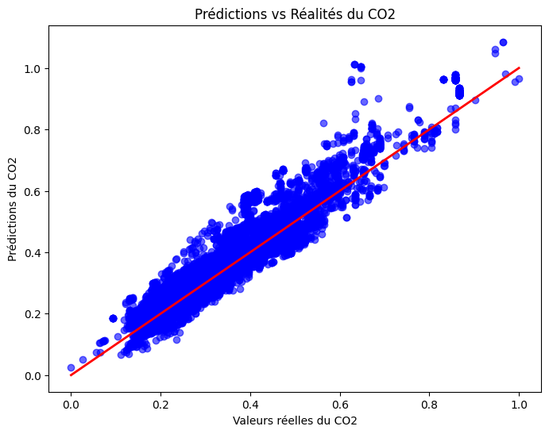

png

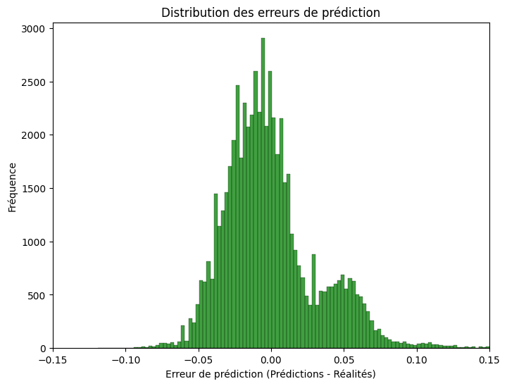

png

```python
# Visualisation des prédictions vs valeurs réelles
plt.figure(figsize=(8, 6))
plt.scatter(y_test, y_pred, color='blue', alpha=0.6)
plt.plot([min(y_test), max(y_test)], [min(y_test), max(y_test)], color='red', linewidth=2)
plt.title('Prédictions vs Réalités du CO2')
plt.xlabel('Valeurs réelles du CO2')
plt.ylabel('Prédictions du CO2')
plt.show()

# Visualisation de l'erreur de prédiction
plt.figure(figsize=(8, 6))
errors = y_pred - y_test
sns.histplot(errors, color='green', bins=200)
plt.title('Distribution des erreurs de prédiction')
plt.xlabel('Erreur de prédiction (Prédictions - Réalités)')
plt.ylabel('Fréquence')
plt.xlim(-0.15, 0.15)
plt.show()
```

Nous remarquons que les points sont alignés le long de la droite y=x, ce qui indique une bonne correspondance entre les prédictions et les valeurs réelles. La dispersion est faible, surtout pour les valeurs intermédiaires, confirmant la qualité du modèle, déjà soutenue par un R² de 0.860. Cependant, on observe quelques écarts pour les valeurs extrêmes, suggérant que le modèle pourrait être amélioré pour mieux capturer ces cas.

L’histogramme montre une distribution centrée autour de 0, ce qui indique que le modèle est globalement non biaisé. La majorité des erreurs se situent entre -0.05 et 0.05, suggérant une bonne précision des prédictions. Cependant, la distribution est légèrement asymétrique avec une queue plus longue à droite, ce qui est cohérent avec les tests de normalité (Shapiro-Wilk et Lilliefors) indiquant une non-normalité des résidus.

### **6.4- Ridge**

```
Alpha: 1, MSE: 5.4645710044432657e-05, R²: 0.993392493031036
```

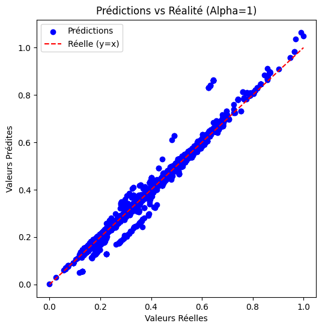

png

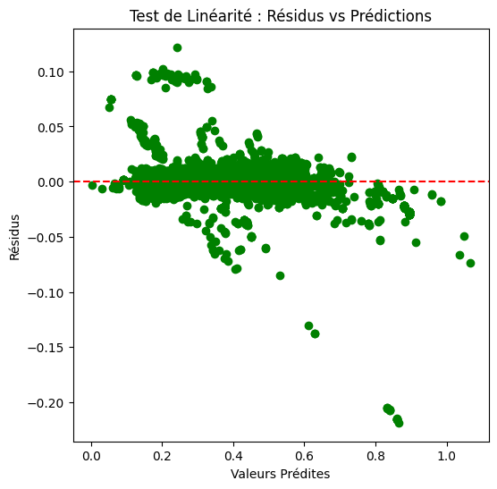

png

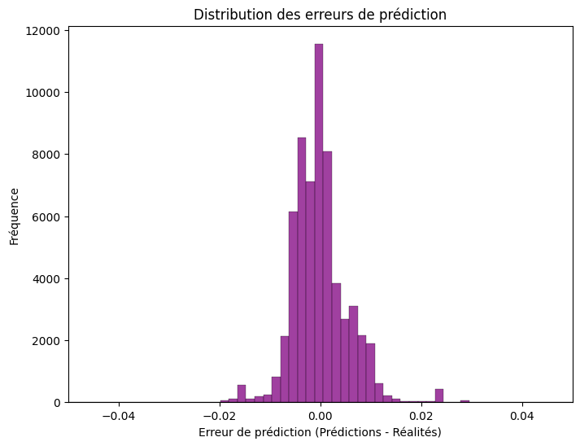

png

```python
import numpy as np
import pandas as pd
import matplotlib.pyplot as plt
from sklearn.linear_model import Ridge, Lasso
from sklearn.model_selection import train_test_split
from sklearn.metrics import mean_squared_error

# Séparation des données
X_train, X_test, y_train, y_test = train_test_split(test, y, test_size=0.2, random_state=42)

# Régression Ridge
ridge = Ridge(alpha=1)
ridge.fit(X_train, y_train)

# Prédictions sur l'ensemble de test
y_pred = ridge.predict(X_test)

# Calcul du MSE
mse = mean_squared_error(y_test, y_pred)

# Calcul du R² (coefficient de détermination)
r2 = ridge.score(X_test, y_test)  # Le score est déjà le R²

print(f"Alpha: {1}, MSE: {mse}, R²: {r2}")

# Graphique Prédictions vs Réalité
plt.figure(figsize=(6, 6))
plt.scatter(y_test, y_pred, color='blue', label="Prédictions")
plt.plot([min(y_test), max(y_test)], [min(y_test), max(y_test)], color='red', linestyle='--', label="Réelle (y=x)")
plt.xlabel("Valeurs Réelles")
plt.ylabel("Valeurs Prédites")
plt.title(f"Prédictions vs Réalité (Alpha={1})")
plt.legend()
plt.show()

# Test de linéarité : Résidus vs Prédictions
residuals = y_test - y_pred

plt.figure(figsize=(6, 6))
plt.scatter(y_pred, residuals, color='green')
plt.axhline(y=0, color='red', linestyle='--')
plt.xlabel("Valeurs Prédites")
plt.ylabel("Résidus")
plt.title("Test de Linéarité : Résidus vs Prédictions")
plt.show()

# Visualisation de l'erreur de prédiction
plt.figure(figsize=(8, 6))
errors = y_pred - y_test
sns.histplot(errors, color='purple', bins=200)
plt.title('Distribution des erreurs de prédiction')
plt.xlabel('Erreur de prédiction (Prédictions - Réalités)')
plt.ylabel('Fréquence')
plt.xlim(-0.05, 0.05)
plt.show()
```

### **6.5- Lasso**

```
MSE: 0.008270252175456178, R²: -7.107599726552394e-07
```

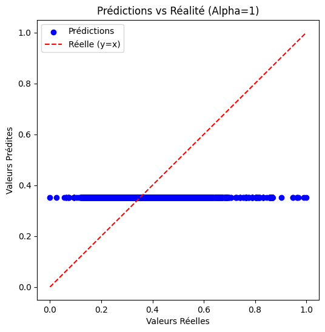

png

```python
import numpy as np
import pandas as pd
from sklearn.linear_model import Lasso
from sklearn.model_selection import train_test_split
from sklearn.metrics import mean_squared_error
import matplotlib.pyplot as plt

lasso = Lasso(alpha=1)
lasso.fit(X_train, y_train)

# Prédictions sur l'ensemble de test
y_pred = lasso.predict(X_test)

# Calcul du MSE
mse = mean_squared_error(y_test, y_pred)

# Calcul du R² (coefficient de détermination)
r2 = lasso.score(X_test, y_test)  # Le score est déjà le R²

print(f"MSE: {mse}, R²: {r2}")

    # Graphique Prédictions vs Réalité
plt.figure(figsize=(6, 6))
plt.scatter(y_test, y_pred, color='blue', label="Prédictions")
plt.plot([min(y_test), max(y_test)], [min(y_test), max(y_test)], color='red', linestyle='--', label="Réelle (y=x)")
plt.xlabel("Valeurs Réelles")
plt.ylabel("Valeurs Prédites")
plt.title(f"Prédictions vs Réalité (Alpha={1})")
plt.legend()
plt.show()
```

### **6.6- OLS**

```python
import pandas as pd
import statsmodels.api as sm
import matplotlib.pyplot as plt

# Charger les données
X = df["Consommation mixte"]
y = df["CO2"]

X_const = sm.add_constant(X)  # Ajout de la constante pour le terme b
model = sm.OLS(y, X_const)  # Créer le modèle OLS
results = model.fit()  # Ajuster le modèle aux données

# Afficher le résumé des résultats
print(results.summary())
```

```
                            OLS Regression Results
==============================================================================
Dep. Variable:                    CO2   R-squared:                       0.950
Model:                            OLS   Adj. R-squared:                  0.950
Method:                 Least Squares   F-statistic:                 5.845e+06
Date:                Fri, 21 Mar 2025   Prob (F-statistic):               0.00
Time:                        12:56:39   Log-Likelihood:             7.5768e+05
No. Observations:              305701   AIC:                        -1.515e+06
Df Residuals:                  305699   BIC:                        -1.515e+06
Df Model:                           1
Covariance Type:            nonrobust
======================================================================================
                         coef    std err          t      P>|t|      [0.025      0.975]
--------------------------------------------------------------------------------------
const                  0.0356      0.000    261.898      0.000       0.035       0.036
Consommation mixte     1.0127      0.000   2417.634      0.000       1.012       1.014
==============================================================================
Omnibus:                   179443.258   Durbin-Watson:                   0.572
Prob(Omnibus):                  0.000   Jarque-Bera (JB):          4710864.007
Skew:                          -2.348   Prob(JB):                         0.00
Kurtosis:                      21.649   Cond. No.                         12.5
==============================================================================

Notes:
[1] Standard Errors assume that the covariance matrix of the errors is correctly specified.
```

### **6.7- Tests Statistiques**

```python
# Calcul des résidus
residuals = results.resid

# Test de Shapiro-Wilk (Normalité)
shapiro_stat, shapiro_p_value = stats.shapiro(residuals)

# Test de Lilliefors (Normalité)
lilliefors_stat, lilliefors_p_value = lilliefors(residuals)

# Test de Ljung-Box (Autocorrélation des résidus)
ljungbox_stat, ljungbox_p_value = acorr_ljungbox(residuals, lags=10)  # Par défaut, 10 lags

# Test de Box-Pierce (Autocorrélation des résidus)
boxpierce = sm.stats.acorr_ljungbox(residuals, boxpierce=True, lags=[10], return_df=True)

# Test de Breusch-Godfrey (Autocorrélation)
breuschgodfrey = acorr_breusch_godfrey(results, nlags=10)

# Test de Durbin-Watson (Autocorrélation des résidus)
dw_stat = durbin_watson(residuals)

# Test de Linear Rainbow (Linéarité)
rainbow_stat, rainbow_p_value = linear_rainbow(results)

# Test de Student (Hypothèse de significativité des coefficients)
student_stat, student_p_value = stats.ttest_1samp(residuals, 0)  # Test de Student sur les résidus

# Test de Fisher (significativité globale du modèle)
f_stat = results.fvalue
f_p_value = results.f_pvalue  #

# Affichage des résultats
print(f"Shapiro-Wilk Test: Stat = {shapiro_stat}, p-value = {shapiro_p_value}")
print(f"Lilliefors Test: Stat = {lilliefors_stat}, p-value = {lilliefors_p_value}")
print(f"Ljung-Box Test: Stat = {ljungbox_stat}, p-value = {ljungbox_p_value}")
print(f"Ljung-Box Test: Stat = {boxpierce['lb_stat'].values[0]}, p-value = {boxpierce['lb_pvalue'].values[0]}")
print(f"Box-Pierce Test: Stat = {boxpierce['bp_stat'].values[0]}, p-value = {boxpierce['bp_pvalue'].values[0]}")
print(f"Breusch-Godfrey Test: Stat = {breuschgodfrey[0]}, p-value = {breuschgodfrey[1]}")
print(f"Durbin-Watson Test: Stat = {dw_stat}")
print(f"Linear Rainbow Test: Stat = {rainbow_stat}, p-value = {rainbow_p_value}")
print(f"Student's t-test: Stat = {student_stat}, p-value = {student_p_value}")
print(f"Fisher Test: Stat = {f_stat}, p-value = {f_p_value}")
```

[output not shown]

### **6.8- PLS**

```python
from sklearn.cross_decomposition import PLSRegression

pls = PLSRegression(n_components=8)
pls.fit(X_train, y_train)
y_pls_pred = pls.predict(X_test)
mse_pls = np.mean((y_pls_pred - y_test) ** 2)
rmse_pls = np.sqrt(mse_pls)
r2_pls = pls.score(X_test, y_test)
y_pred = pls.predict(X_test)
print(f"PLS - MSE : {mse_pls:.2f}, RMSE : {rmse_pls:.2f}, R² : {r2_pls:.4f}")
```

```
PLS - MSE : 0.00, RMSE : 0.01, R² : 0.9934
```

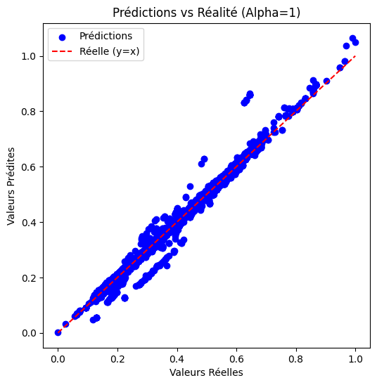

png

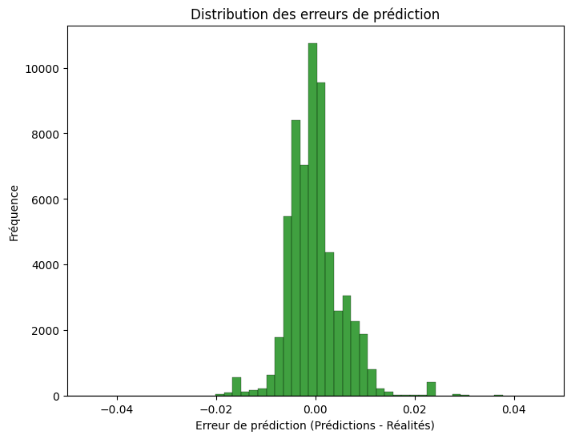

png

```python
plt.figure(figsize=(6, 6))
plt.scatter(y_test, y_pred, color='blue', label="Prédictions")
plt.plot([min(y_test), max(y_test)], [min(y_test), max(y_test)], color='red', linestyle='--', label="Réelle (y=x)")
plt.xlabel("Valeurs Réelles")
plt.ylabel("Valeurs Prédites")
plt.title(f"Prédictions vs Réalité (Alpha={1})")
plt.legend()
plt.show()

# Visualisation de l'erreur de prédiction
plt.figure(figsize=(8, 6))
errors = y_pred - y_test
sns.histplot(errors, color='green', bins=200)
plt.title('Distribution des erreurs de prédiction')
plt.xlabel('Erreur de prédiction (Prédictions - Réalités)')
plt.ylabel('Fréquence')
plt.xlim(-0.05, 0.05)
plt.show()
```

### **7- CONCLUSION**

### Tableau de Diagnostic à Postériori

| Hypothèse | Test effectué | Résultat | Conclusion |
| --- | --- | --- | --- |
| 1. Linéarité | Test de Rainbow | p-value = 0.0970815647070203 | Validée |
| 2. Multicolinéarité | VIF (Variance Inflation Factor) | Valeurs entre 1 et 13,5 | Partiellement validée |
| 3. Normalité des résidus | Test de Shapiro-Wilk | p-value = 8.128534648134912e-153 | Rejetée |
|  | Test de Lilliefors | p-value = 0.000999999999998899 | Rejetée |
| 4. Indépendance des résidus | Test de Durbin-Watson | Valeur = 1.9975894321639842 | Validée |
|  | Test de Ljung-Box | p-value = 0.4625060195973161 | Validée |
|  | Test de Box-Pierce | p-value = 0.4625323662073837 | Validée |
|  | Test de Breusch-Godfrey | p-value = 0.6259846732406785 | Validée |

Cependant, nous avons également identifié des défis, notamment la non-normalité des résidus dans les modèles de régression, ce qui suggère que des transformations des données ou des approches alternatives pourraient être nécessaires pour améliorer encore la précision des prédictions.

```r
knitr::opts_chunk$set(echo = FALSE,warning=FALSE,message=FALSE)
```

```r
# Définir un miroir CRAN
options(repos = "https://cran.r-project.org/")  # Miroir principal de CRAN
```